# Индивидуальный проект этап № 5

Использование Burp Suite

Мальянц Виктория Кареновна

1132246740@rudn.ru

Российский университет дружбы народов

2026-04-19

# Цель работы

- Приобретение практических навыков по использованию Burp Suite.

# Задание

- Приобретение практических навыков по использованию Burp Suite

# Выполнение лабораторной работы

## Приобретение практических навыков по использованию Burp Suite

- Запускаю apache2 и mysql (рис. 1).

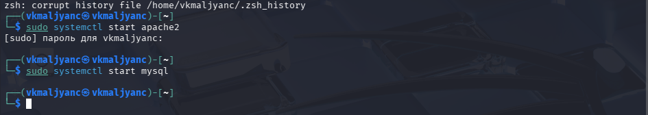

Запуск apache2 и mysql

## Приобретение практических навыков по использованию Burp Suite

- Запускаю Burp Suite (рис. 2).

[figure not shown]

Запуск Burp Suite

## Приобретение практических навыков по использованию Burp Suite

- Открываю сетевые настройки браузера (рис. 3).

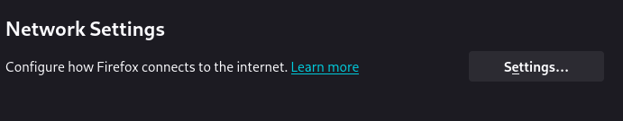

Открытие сетевых настроек браузера

## Приобретение практических навыков по использованию Burp Suite

- Изменяю настройки сервера для работы с proxy и захватом данных с помощью инструмента Burp Suite (рис. 4).

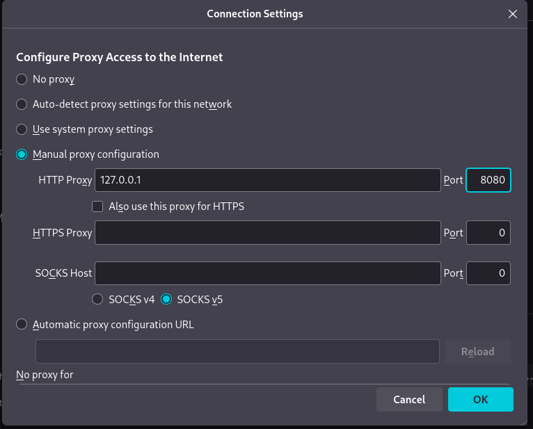

Изменение настроек сервера

## Приобретение практических навыков по использованию Burp Suite

- Изменяю настройки Proxy инструмента Burp Suite (рис. 5).

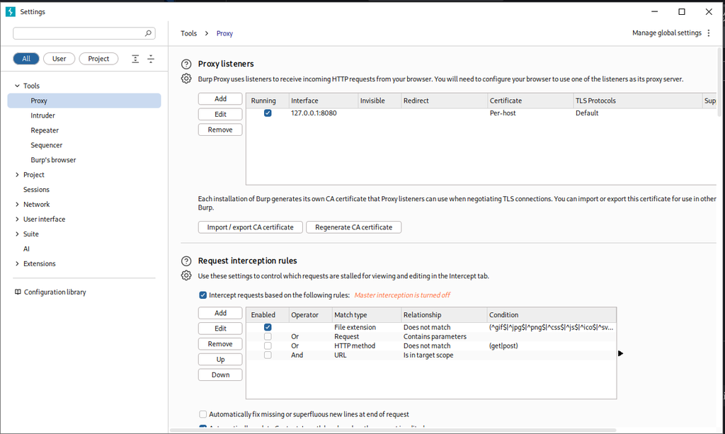

Изменение настроек Proxy инструмента Burp Suite

## Приобретение практических навыков по использованию Burp Suite

- Во вкладке Proxy устанавливаю Intercept on (рис. 6).

[figure not shown]

Во вкладке Proxy установка Intercept on

## Приобретение практических навыков по использованию Burp Suite

- Запускаю страницу в браузере, запрос виден в Burp Suite (рис. 8).

[figure not shown]

Запуск страницы в браузере

## Приобретение практических навыков по использованию Burp Suite

- Загружаю страницу с помощью Forward (рис. 9).

[figure not shown]

Загрузка страницы с помощью Forward

## Приобретение практических навыков по использованию Burp Suite

- Во вкладке Target сохраняется история запросов (рис. 10).

[figure not shown]

Во вкладке Target сохранение истории запросов

## Приобретение практических навыков по использованию Burp Suite

- Нажимаю на запрос и далее на кнопку Send to intruder (рис. 11).

[figure not shown]

Нажимание на запрос и далее на кнопку Send to intruder

## Приобретение практических навыков по использованию Burp Suite

- Во вкладке Intruder меняю тип атаки на Cluster bomb attack и выделяю специальными символами данные в форме для ввода (рис. 12).

[figure not shown]

Во вкладке Intruder изменение типа атаки на Cluster bomb attack и выделение специальными символами данных в форме для ввода

## Приобретение практических навыков по использованию Burp Suite

- Добавляю значения в список для подбора у Payload position: 1 - 12345 (рис. 13).

[figure not shown]

Добавление значений в список для подбора у Payload position: 1 - 12345

## Приобретение практических навыков по использованию Burp Suite

- Добавляю значения в список для подбора у Payload position: 2 - 12345 (рис. 14).

[figure not shown]

Добавление значений в список для подбора у Payload position: 2 - 12345

## Приобретение практических навыков по использованию Burp Suite

- Запускаю атаку. Выбираю комбинацию 1234567 admin. У нее Location: login.php, значит она не подходит (рис. 15).

[figure not shown]

Запуск атаки и выбор комбинации 1234567 admin

## Приобретение практических навыков по использованию Burp Suite

- Выбираю комбинацию admin password. У нее Location: index.php, значит она подходит (рис. 16).

[figure not shown]

Выбор комбинации admin password

## Приобретение практических навыков по использованию Burp Suite

- Нажимаю на комбинацию admin password и далее на кнопку Send to Repeater (рис. 17).

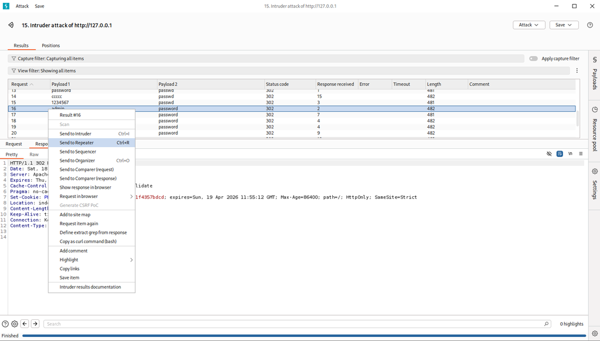

Нажимание на комбинацию admin password и далее на кнопку Send to Repeater

## Приобретение практических навыков по использованию Burp Suite

- Во вкладке Repeater нажимаю на кнопку Follow redirection (рис. 18).

[figure not shown]

Во вкладке Repeater нажимание на кнопку Follow redirection

## Приобретение практических навыков по использованию Burp Suite

- Нажимаю на Request in browser, далее на In original session (рис. 19).

[figure not shown]

Нажимание на Request in browser, далее на In original session

## Приобретение практических навыков по использованию Burp Suite

- Копирую ссылку на страницу (рис. 20).

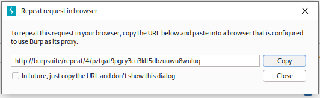

Копирование ссылки на страницу

## Приобретение практических навыков по использованию Burp Suite

- Вставляю ссылку в браузер, страница открылась (рис. 21).

[figure not shown]

Вставка ссылки в браузер, открытие страницы

# Выводы

- Я приобрела практические навыки по использованию Burp Suite.

# Спасибо за внимание